# CH3_4_HW

Steph Jordan

1/6/2022

```r
library("tidyverse")
```

```r
library("ggplot2")
```

## Chapter 3

1. A variable is many observations of the same measurement. We can categorize variables into several groups (categorical, continuous, ordinal, count, and qualitative).

2a. Ordinal

2b. Categorical

2c. Count

2d. Continuous

2e. Count

2f. Count

2g. Qualitative

2h. Qualitative

2i. Ordinal

3. B (distribution)

4a. Calculating average salary

```r
num <- (85000*5+90000*4+100000+120000*2+125000*3+130000*2)
denom <- (5+4+1+2+3+2)
num/denom
```

```
## [1] 103529.4
```

4b. Median salary: $90,000

4c. Min: 85,000; Max: 130000

4d. Calculating IQR:

```r
twfifth_percentile <- 85000
sevfifth_percentile <- 125000
sevfifth_percentile - twfifth_percentile
```

```
## [1] 40000
```

5. C (Greek letters)
6. A (Log transforming the variable)
7. D, A, C, B

8a. The distribution has a median close to 80 and is slightly right skewed, meaning the mean is likely a bit higher than 80. It has a range of 15, and is slightly bimodal.

8b. Yes, the distribution is slightly right skewed.

8c. The median would be better, because due to the slight dominance of higher values (as indicated by the right skew), the mean will be slightly pulled up by these higher outliers. Therefore, the median will more closely reflect the center of the distribution.

8d. IQR could be used to describe the variability of the distribution, as could standard error.

9. B (mean is less than median)

10a. Ordinal

10b. Count

10c. Graphing the data

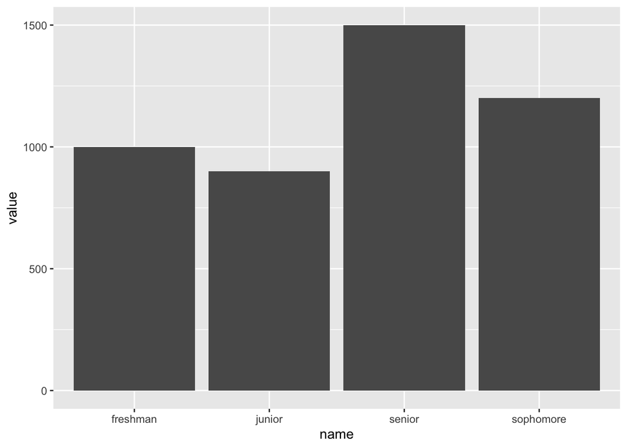

```r
data <- data.frame(
  name=c("freshman","sophomore","junior","senior") ,
  value=c(1000, 1200, 900, 1500)
  )

ggplot(data, aes(x=name, y=value)) +
  geom_bar(stat = "identity")
```

11a. Using data from my family’s heights:

```r
data <- c(63, 73, 68, 65, 70)

mean(data)
```

```
## [1] 67.8
```

```r
median(data)
```

```
## [1] 68
```

```r
max(data)-min(data)
```

```
## [1] 10
```

```r
sd(data)
```

```
## [1] 3.962323
```

```r
IQR(data)
```

```
## [1] 5
```

The mean and median are very similar (67.8 vs 68) and therefore the distribution is likely fairly symmetric. The min and max are also equidistant from the median, which implies some symmetry. This is also evident in the standard deviation, which is relatively small (3.96).

11b. A normal distribution is likely to have generated this dataset, especially given that it is a physical characteristic (height).

11c. I think we would need more data to confirm this. Though we know that heights generally distribute normally, concluding this based on a sample of only 5 datapoints from one family would be presumptious.

## Chapter 4

1. A conditional distribution is one that illustrates the observed value of a given variable under a range of different conditions (in which one or more other variables are allowed to vary).

2a. We can’t say anything about the conditional mean, since the graph does not demonstrate a conditional distribution, but rather an unconditional distribution.

2b. No, because we cannot conclude causality from correlation. In order to make a causal claim about depression and income, we would need a more robust research design that allowed for control over potential confounding variables.

3a. Calculating probability of receiving fin aid if senior:

```r
288/(288+338)
```

```
## [1] 0.4600639
```

3b. Calculating probability of senior if fin aid:

```r
288/(288+425+349+508)
```

```
## [1] 0.1834395
```

3c. Calculating probability of receiving fin aid if freshman:

```r
508/(371+508)
```

```
## [1] 0.5779295
```

4.Advantages: 1) local means may miss filling in gaps in your data, while line-fitting will provide an estimation across the entire range of x values; 2) local means are difficult to describe concisely; a line-fitting method allows you to describe a relationship in a single equation. Disadvantage: local means may provide a more precise illustration of the relationship between X and Y; when the relationship is nonlinear, line-fitting may represent a distorted or oversimplified version of the relationship.

5a. Calculating conditional predicted mean of Y when X=6:

```r
4-3.5*6
```

```
## [1] -17
```

5b. Calculating conditional predicted mean of Y when X=-2:

```r
4-3.5*(-2)
```

```
## [1] 11
```

6. C (covariance)
7. Covariance describes how two variables move together or apart; correlation is a scaled version of covariance. The correlation coefficient describes for a one standard deviation increase in one variable, how much change (increase or decrease) occurs in the other variable. The correlation coefficient is calculated by taking the covariance between X and Y and dividing by both the standard deviation of X and the standard deviation of Y.

8a. Linear

8b. Quadratic (parabolic)

8c. B (the parabolic) shape is a better fit for this data; this is evident from the fact that the linear trend line misses many of the points, especially at the low and high ends of the x range, which means that the residual values for the linear trend line are much higher. Therefore, the parabolic line is a better fit.

8d. For low values of x, the residuals are positive (observed points lie above trend line). For mid-range values of x, the residuals are negative (observed points lie below trend line). For high values of x, the residuals are again positive (observed points lie above trend line).

9a. Filling in residual column

```r
data <- data.frame(
  satisfaction=c(5.07, 4.05, 5.33, 4.02, 3.59),
  prediction=c(4.72, 4.28, 5.38, 4.22, 3.45)
  ) |> mutate (residual=satisfaction-prediction)

data
```

```
##   satisfaction prediction residual
## 1         5.07       4.72     0.35
## 2         4.05       4.28    -0.23
## 3         5.33       5.38    -0.05
## 4         4.02       4.22    -0.20
## 5         3.59       3.45     0.14
```

9b. OLS attempts to minimize the square of the residual value for each point. When the line that minimizes the sum of the square of the residual for all points is discovered, this is chosen as the OLS line.

10a. SES–if first-generation students generally have lower SES than non-first-generation students, then it could be the lack of financial resources and stability associated with first generation students that causes them to have lower graduation rate, rather than their first-generation status.

10b. 5 steps to control for SES:

1. get the mean of graduation rate conditional on SES
2. subtract out the conditional mean found in step 1 from graduation rate. This yields the residual of graduation rate (call this Y_r).
3. get the mean of first generation conditional on SES
4. subtract out the conditional mean found in step 3 from first generation. This yields the residual of first generation (call this X_r).
5. compare X_r and Y_r. Describe the relationship between the two. Since we have removed the part of the relationship between graduation rate and first generation status that is explained by SES, we are left with the relationship between graduation rate and first generation status that is not explained by SES.

10c. The process described in part b yields the mean of graduation rate conditional on first generation conditional on SES. We have deducted the part of the relationship between graduation rate and first generation status that is explained by SES, so we have effectively controlled for SES.